# Progress Memo 1

Final Project  
Data Science 2 with R (STAT 301-2)

Author

Chelsea Nelson

Published

March 14, 2024

**Github Repo Link**

[Final Project II - Progress Memo I](https://github.com/stat301-2-2024-winter/final-project-2-chelseanelson)

## Prediction Problem

For this project, my prediction objective is to predict which diabetes diagnoses based on general health questions. This objective is a classification problem, as there are up to three different classes that someone could identify with in terms of their diabetes diagnosis: not having diabetes, being prediabetic, or being diabetic.

My motivation for pursuing this particular problem is because I am interested in seeing what factors of everyday life seem play a role in the diagnosing of diabetes. Additionally, as I will go into later in the memo, the datasets that I am using are fairly large, so I hope to see and engage with them in meaningful manners to be able to challenge and showcase my skills that I have learned throughout the quarter.

## Data source

I will be using the Centers for Disease Control and Prevention’s (CDC) survey data from their Behavioral Risk Factor Surveillance System (BRFSS) which is a health-related telephone survey. Although looking, at multiple aspects of life through these telephone surveys, specific Diabetes Health Indicators Dataset, that I will be looking at, contains statistics and lifestyle survey information about people in general along with their diagnosis of diabetes. Currently, I have two versions of the dataset, one that is extremely larger, having over 250,000 instances, while also looking at the diabetes diagnoses of having no diabetes, prediabetes, and or diabetes. The other version of the dataset is much smaller, having around 70,000 instances, while also only looking at the diabetes diagnoses of having no diabetes or having diabetes. Furthermore, whereas the former does not have a balance or equality in the distribution of the different diagnoses of diabetes, the later has an equal 50-50 split between the two diagnoses. Thus going forward for Progress Memo 2 and the rest of my project, I will have to figure out which dataset I will exactly be using. This is something I will possible go to ask the professor and or TAs for their opinions on the matter as well. Both of the versions were found on the same Kaggle website.[^1]

<sup>1</sup> These datasets were sourced from [Kaggle Diabetes Health Indicators Dataset](https://www.kaggle.com/datasets/alexteboul/diabetes-health-indicators-dataset/data?select=diabetes_012_health_indicators_BRFSS2015.csv).

## Why this data

The reason I choose this dataset is because I thought it would be interesting to see what factors of general life play a role in the prediction and truth behind if a person has diabetes or not. Furthermore, because I am dealing with extremely large datasets, I think this would be an excellent moment to challenge myself more on applying what I am learning in class to such an interesting and full dataset in which I can use different predictors and try to find different and the best ways to gain accurate predictions through my models.

## Data quality & complexity check

#### Diabetes Health Indicators Dataset (Larger Version)

```r
diabetes_data_large <- read_csv(here("data/raw/diabetes_012_health_indicators_BRFSS2015.csv")) %>%
  janitor::clean_names()

diabetes_data_large %>% slice_head(n = 200) %>% DT::datatable()
```

|  | diabetes_012 | high_bp | high_chol | chol_check | bmi | smoker | stroke | heart_diseaseor_attack | phys_activity | fruits | veggies | hvy_alcohol_consump | any_healthcare | no_docbc_cost | gen_hlth | ment_hlth | phys_hlth | diff_walk | sex | age | education | income |
| --- | --- | --- | --- | --- | --- | --- | --- | --- | --- | --- | --- | --- | --- | --- | --- | --- | --- | --- | --- | --- | --- | --- |
| 1 | 0 | 1 | 1 | 1 | 40 | 1 | 0 | 0 | 0 | 0 | 1 | 0 | 1 | 0 | 5 | 18 | 15 | 1 | 0 | 9 | 4 | 3 |
| 2 | 0 | 0 | 0 | 0 | 25 | 1 | 0 | 0 | 1 | 0 | 0 | 0 | 0 | 1 | 3 | 0 | 0 | 0 | 0 | 7 | 6 | 1 |
| 3 | 0 | 1 | 1 | 1 | 28 | 0 | 0 | 0 | 0 | 1 | 0 | 0 | 1 | 1 | 5 | 30 | 30 | 1 | 0 | 9 | 4 | 8 |
| 4 | 0 | 1 | 0 | 1 | 27 | 0 | 0 | 0 | 1 | 1 | 1 | 0 | 1 | 0 | 2 | 0 | 0 | 0 | 0 | 11 | 3 | 6 |
| 5 | 0 | 1 | 1 | 1 | 24 | 0 | 0 | 0 | 1 | 1 | 1 | 0 | 1 | 0 | 2 | 3 | 0 | 0 | 0 | 11 | 5 | 4 |
| 6 | 0 | 1 | 1 | 1 | 25 | 1 | 0 | 0 | 1 | 1 | 1 | 0 | 1 | 0 | 2 | 0 | 2 | 0 | 1 | 10 | 6 | 8 |
| 7 | 0 | 1 | 0 | 1 | 30 | 1 | 0 | 0 | 0 | 0 | 0 | 0 | 1 | 0 | 3 | 0 | 14 | 0 | 0 | 9 | 6 | 7 |
| 8 | 0 | 1 | 1 | 1 | 25 | 1 | 0 | 0 | 1 | 0 | 1 | 0 | 1 | 0 | 3 | 0 | 0 | 1 | 0 | 11 | 4 | 4 |
| 9 | 2 | 1 | 1 | 1 | 30 | 1 | 0 | 1 | 0 | 1 | 1 | 0 | 1 | 0 | 5 | 30 | 30 | 1 | 0 | 9 | 5 | 1 |
| 10 | 0 | 0 | 0 | 1 | 24 | 0 | 0 | 0 | 0 | 0 | 1 | 0 | 1 | 0 | 2 | 0 | 0 | 0 | 1 | 8 | 4 | 3 |

[output cut: 190 more lines]

#### Diabetes Health Indicators Dataset (Smaller Version)

```r
diabetes_data_small <- read_csv(here("data/raw/diabetes_binary_5050split_health_indicators_BRFSS2015.csv")) %>%
  janitor::clean_names()

diabetes_data_small %>% slice_head(n = 200) %>% DT::datatable()
```

|  | diabetes_binary | high_bp | high_chol | chol_check | bmi | smoker | stroke | heart_diseaseor_attack | phys_activity | fruits | veggies | hvy_alcohol_consump | any_healthcare | no_docbc_cost | gen_hlth | ment_hlth | phys_hlth | diff_walk | sex | age | education | income |
| --- | --- | --- | --- | --- | --- | --- | --- | --- | --- | --- | --- | --- | --- | --- | --- | --- | --- | --- | --- | --- | --- | --- |
| 1 | 0 | 1 | 0 | 1 | 26 | 0 | 0 | 0 | 1 | 0 | 1 | 0 | 1 | 0 | 3 | 5 | 30 | 0 | 1 | 4 | 6 | 8 |
| 2 | 0 | 1 | 1 | 1 | 26 | 1 | 1 | 0 | 0 | 1 | 0 | 0 | 1 | 0 | 3 | 0 | 0 | 0 | 1 | 12 | 6 | 8 |
| 3 | 0 | 0 | 0 | 1 | 26 | 0 | 0 | 0 | 1 | 1 | 1 | 0 | 1 | 0 | 1 | 0 | 10 | 0 | 1 | 13 | 6 | 8 |
| 4 | 0 | 1 | 1 | 1 | 28 | 1 | 0 | 0 | 1 | 1 | 1 | 0 | 1 | 0 | 3 | 0 | 3 | 0 | 1 | 11 | 6 | 8 |
| 5 | 0 | 0 | 0 | 1 | 29 | 1 | 0 | 0 | 1 | 1 | 1 | 0 | 1 | 0 | 2 | 0 | 0 | 0 | 0 | 8 | 5 | 8 |
| 6 | 0 | 0 | 0 | 1 | 18 | 0 | 0 | 0 | 1 | 1 | 1 | 0 | 0 | 0 | 2 | 7 | 0 | 0 | 0 | 1 | 4 | 7 |
| 7 | 0 | 0 | 1 | 1 | 26 | 1 | 0 | 0 | 1 | 1 | 1 | 1 | 1 | 0 | 1 | 0 | 0 | 0 | 1 | 13 | 5 | 6 |
| 8 | 0 | 0 | 0 | 1 | 31 | 1 | 0 | 0 | 0 | 1 | 1 | 0 | 1 | 0 | 4 | 0 | 0 | 0 | 1 | 6 | 4 | 3 |
| 9 | 0 | 0 | 0 | 1 | 32 | 0 | 0 | 0 | 1 | 1 | 1 | 0 | 1 | 0 | 3 | 0 | 0 | 0 | 0 | 3 | 6 | 8 |
| 10 | 0 | 0 | 0 | 1 | 27 | 1 | 0 | 0 | 0 | 1 | 1 | 0 | 1 | 0 | 3 | 0 | 6 | 0 | 1 | 6 | 4 | 4 |

[output cut: 190 more lines]

### Skimming Datasets

#### Diabetes Health Indicators Dataset (Larger Version)

Data summary

| Name | Piped data |
| --- | --- |
| Number of rows | 253680 |
| Number of columns | 22 |
| _______________________ |  |
| Column type frequency: |  |
| numeric | 22 |
| ________________________ |  |
| Group variables | None |

**Variable type: numeric**

| skim_variable | n_missing | complete_rate | mean | sd | p0 | p25 | p50 | p75 | p100 |
| --- | --- | --- | --- | --- | --- | --- | --- | --- | --- |
| diabetes_012 | 0 | 1 | 0.30 | 0.70 | 0 | 0 | 0 | 0 | 2 |
| high_bp | 0 | 1 | 0.43 | 0.49 | 0 | 0 | 0 | 1 | 1 |
| high_chol | 0 | 1 | 0.42 | 0.49 | 0 | 0 | 0 | 1 | 1 |
| chol_check | 0 | 1 | 0.96 | 0.19 | 0 | 1 | 1 | 1 | 1 |
| bmi | 0 | 1 | 28.38 | 6.61 | 12 | 24 | 27 | 31 | 98 |
| smoker | 0 | 1 | 0.44 | 0.50 | 0 | 0 | 0 | 1 | 1 |
| stroke | 0 | 1 | 0.04 | 0.20 | 0 | 0 | 0 | 0 | 1 |
| heart_diseaseor_attack | 0 | 1 | 0.09 | 0.29 | 0 | 0 | 0 | 0 | 1 |
| phys_activity | 0 | 1 | 0.76 | 0.43 | 0 | 1 | 1 | 1 | 1 |
| fruits | 0 | 1 | 0.63 | 0.48 | 0 | 0 | 1 | 1 | 1 |
| veggies | 0 | 1 | 0.81 | 0.39 | 0 | 1 | 1 | 1 | 1 |
| hvy_alcohol_consump | 0 | 1 | 0.06 | 0.23 | 0 | 0 | 0 | 0 | 1 |
| any_healthcare | 0 | 1 | 0.95 | 0.22 | 0 | 1 | 1 | 1 | 1 |
| no_docbc_cost | 0 | 1 | 0.08 | 0.28 | 0 | 0 | 0 | 0 | 1 |
| gen_hlth | 0 | 1 | 2.51 | 1.07 | 1 | 2 | 2 | 3 | 5 |
| ment_hlth | 0 | 1 | 3.18 | 7.41 | 0 | 0 | 0 | 2 | 30 |
| phys_hlth | 0 | 1 | 4.24 | 8.72 | 0 | 0 | 0 | 3 | 30 |
| diff_walk | 0 | 1 | 0.17 | 0.37 | 0 | 0 | 0 | 0 | 1 |
| sex | 0 | 1 | 0.44 | 0.50 | 0 | 0 | 0 | 1 | 1 |
| age | 0 | 1 | 8.03 | 3.05 | 1 | 6 | 8 | 10 | 13 |
| education | 0 | 1 | 5.05 | 0.99 | 1 | 4 | 5 | 6 | 6 |
| income | 0 | 1 | 6.05 | 2.07 | 1 | 5 | 7 | 8 | 8 |

The larger version of the Diabetes Health Indicators Dataset has 22 variables and 253,680 observations. Within this, all of the variables are numerical, however I will have to go back later on to change some of these variable types. There seems to be no instances of missingness data currently.

#### Diabetes Health Indicators Dataset (Smaller Version)

Data summary

| Name | Piped data |
| --- | --- |
| Number of rows | 70692 |
| Number of columns | 22 |
| _______________________ |  |
| Column type frequency: |  |
| numeric | 22 |
| ________________________ |  |
| Group variables | None |

**Variable type: numeric**

| skim_variable | n_missing | complete_rate | mean | sd | p0 | p25 | p50 | p75 | p100 |
| --- | --- | --- | --- | --- | --- | --- | --- | --- | --- |
| diabetes_binary | 0 | 1 | 0.50 | 0.50 | 0 | 0 | 0.5 | 1 | 1 |
| high_bp | 0 | 1 | 0.56 | 0.50 | 0 | 0 | 1.0 | 1 | 1 |
| high_chol | 0 | 1 | 0.53 | 0.50 | 0 | 0 | 1.0 | 1 | 1 |
| chol_check | 0 | 1 | 0.98 | 0.16 | 0 | 1 | 1.0 | 1 | 1 |
| bmi | 0 | 1 | 29.86 | 7.11 | 12 | 25 | 29.0 | 33 | 98 |
| smoker | 0 | 1 | 0.48 | 0.50 | 0 | 0 | 0.0 | 1 | 1 |
| stroke | 0 | 1 | 0.06 | 0.24 | 0 | 0 | 0.0 | 0 | 1 |
| heart_diseaseor_attack | 0 | 1 | 0.15 | 0.35 | 0 | 0 | 0.0 | 0 | 1 |
| phys_activity | 0 | 1 | 0.70 | 0.46 | 0 | 0 | 1.0 | 1 | 1 |
| fruits | 0 | 1 | 0.61 | 0.49 | 0 | 0 | 1.0 | 1 | 1 |
| veggies | 0 | 1 | 0.79 | 0.41 | 0 | 1 | 1.0 | 1 | 1 |
| hvy_alcohol_consump | 0 | 1 | 0.04 | 0.20 | 0 | 0 | 0.0 | 0 | 1 |
| any_healthcare | 0 | 1 | 0.95 | 0.21 | 0 | 1 | 1.0 | 1 | 1 |
| no_docbc_cost | 0 | 1 | 0.09 | 0.29 | 0 | 0 | 0.0 | 0 | 1 |
| gen_hlth | 0 | 1 | 2.84 | 1.11 | 1 | 2 | 3.0 | 4 | 5 |
| ment_hlth | 0 | 1 | 3.75 | 8.16 | 0 | 0 | 0.0 | 2 | 30 |
| phys_hlth | 0 | 1 | 5.81 | 10.06 | 0 | 0 | 0.0 | 6 | 30 |
| diff_walk | 0 | 1 | 0.25 | 0.43 | 0 | 0 | 0.0 | 1 | 1 |
| sex | 0 | 1 | 0.46 | 0.50 | 0 | 0 | 0.0 | 1 | 1 |
| age | 0 | 1 | 8.58 | 2.85 | 1 | 7 | 9.0 | 11 | 13 |
| education | 0 | 1 | 4.92 | 1.03 | 1 | 4 | 5.0 | 6 | 6 |
| income | 0 | 1 | 5.70 | 2.18 | 1 | 4 | 6.0 | 8 | 8 |

Similar to the larger version, the smaller version of the Diabetes Health Indicators Dataset also has 22 variables, however this time only having 70,692 observations. The variables are again all listed as numerical right now, however I will have to go back and change a lot of these to being categorical. There are no instances of missingness in the dataset.

Overall from skimming both datasets, we can that there is no missingness in the data and that everything has been categorized as a numerical variable. I will have to go back to the dataset and change this so that the all variables but `bmi`, `ment_hlth`, `phys_hlth` are factor variables, as that is their original function and usage.

## Potential data issues

I think the main issues that I could face are using the fairly large datasets in the best manner possible. Additionally I need to work through how I can incorporate in the best manner the lesser amount of numerical variables with that of the more categorical variables in which I will be making and using.

## Target variable analysis

As I said previously the larger version of the dataset is not balanced in terms of the distribution of the three classes of diabetes diagnosis that are present, thus from the figure below, we can see that most people who were included in this dataset did not have diabetes, with that number being around 213,703. The least amount of people were prediabetic, as the number rests at 4,631. Lastly, there are 35,346 people who were diabetic in this dataset. Thus, if I were to use the larger version of the dataset, I would have to take these imbalances into account and most likely use stratified sampling to ensure a good distribution of the data when splitting.

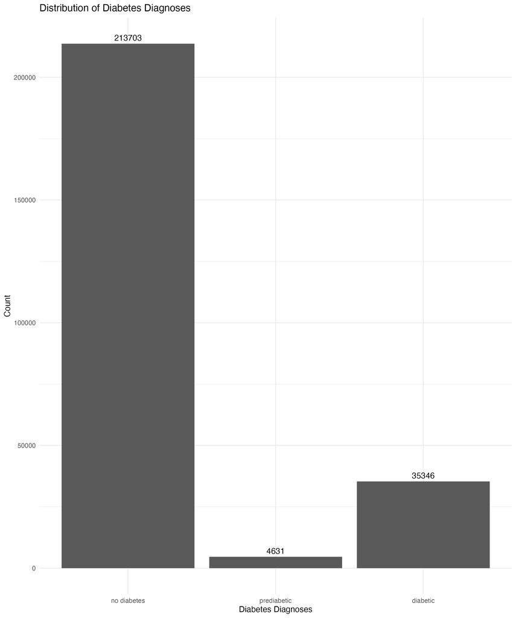

Univariate Analysis - Diabetes Diagnosis (Large Version)

Contrastingly, for the smaller version of the dataset, there is a balance between the amount of people who did and did not have diabetes. When looking at the distribution between the two classes, we see that there is an equal amount of 35346 people included from both sides. Although stratified sampling would most likely not be needed anymore due to the balance in classes, I will still be including it, if I use this version as it is always helpful and tends to help ensure good predictive model building skills. A look at the distribution of the two classes provided in the smaller version of the data can be seen down below.

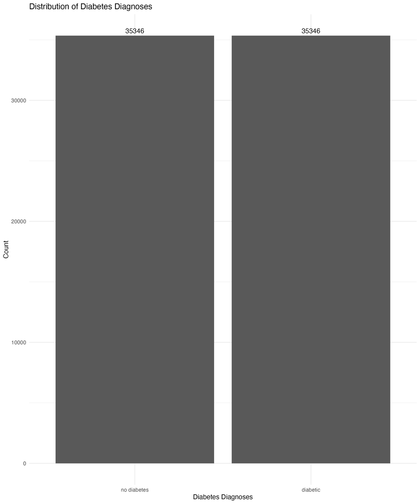

Univariate Analysis - Diabetes Diagnosis (Small Version)

## Misc

Currently, my biggest concern is knowing which of the datasets that I want to use in my actual project. I am currently leaning towards the larger version, as I would find it interesting to do multiclass classification prediction model.